# ICA FINAL PROJECT

## IMPORTING lIBARARIES AND DATA SET

```python
#loading the required libraries
import pandas as pd
from matplotlib import pyplot as plt
import seaborn as sns
import numpy as np
```

IMPORTING LIBARIES TO USE IN CODE pandas is used for handling datasets (loading, cleaning, analyzing).

numpy is for numerical operations.

matplotlib.pyplot and seaborn are for creating visualizations and plots.

```python
missing = ['Na', 'na', '###', 'abc','---','123']
```

```python
data=pd.read_csv("PROPERTYDATA_ICA_PROJECT_FINAL.csv",na_values=missing)
data
```

|  | property_id | location_id | property_type | price | location | city | province_name | latitude | longitude | baths | purpose | bedrooms | date_added | agency | Area Type | Area Size |
| --- | --- | --- | --- | --- | --- | --- | --- | --- | --- | --- | --- | --- | --- | --- | --- | --- |
| 0 | 237062% | 3325% | Flat | 10000000% | G-10 | Islamabad | Islamabad Capital | 33.68% | 73.01% | 2 | For Sale | 2 | 02-Apr-19 | NaN | Marla | 4.0 |
| 1 | 346905% | 3236% | Flat | 6900000% | E-11 | Islamabad | Islamabad Capital | 33.70% | 72.97% | 3 | For Sale | 3 | 05-Apr-19 | NaN | Marla | 5.6 |
| 2 | 386513% | 764% | House | 16500000% | G-15 | Islamabad | Islamabad Capital | 33.63% | 72.93% | 6 | For Sale | 5 | 07-17-2019 | NaN | Marla | 8.0 |
| 3 | 656161% | 340% | House | 43500000% | Bani Gala | Islamabad | Islamabad Capital | 33.71% | 73.15% | 4 | For Sale | 4 | 04-May-19 | NaN | Kanal | 2.0 |
| 4 | 841645% | 3226% | House | 7000000% | DHA Defence | Islamabad | Islamabad Capital | 33.49% | 73.30% | 3 | For Sale | 3 | 07-Oct-19 | Easy Property | Marla | 8.0 |
| ... | ... | ... | ... | ... | ... | ... | ... | ... | ... | ... | ... | ... | ... | ... | ... | ... |
| 4445 | 9195050% | 682% | House | 4500000% | Orangi Town | Karachi | Sindh | 24.95% | 66.97% | 3 | For Sale | 4 | 07-18-2019 | NaN | Marla | 3.2 |
| 4446 | 9195698% | 8482% | Flat | 6500000% | Gadap Town | Karachi | Sindh | 25.06% | 67.05% | 2 | For Sale | 2 | 07-18-2019 | NaN | Marla | 4.4 |
| 4447 | 9196319% | 6841% | Lower Portion | 7300000% | Gulistan-e-Jauhar | Karachi | Sindh | 24.91% | 67.12% | 3 | For Sale | 2 | 07-18-2019 | NaN | Marla | 4.8 |
| 4448 | 9196632% | 476% | House | 5500000% | Malir | Karachi | Sindh | 24.90% | 67.16% | 3 | For Sale | 6 | 07-18-2019 | NaN | Marla | 5.0 |
| 4449 | 9196697% | 6828% | Flat | 7000000% | Gulistan-e-Jauhar | Karachi | Sindh | 24.93% | 67.14% | 2 | For Sale | 2 | 07-18-2019 | NaN | Marla | 4.7 |

4450 rows × 16 columns

This cell reads the data

```python
data.shape
```

[output not shown]

This finds out the number of rows and columns in the data

```python
data.info
```

[output not shown]

This finds out the relevant infromation of values in data It gives us the non-null entries per column It gives us the data type of each column This is useful for understanding the structure of the dataset.

```python
data.isnull().sum()
```

```
property_id         0
location_id         0
property_type       0
price               0
location            0
city                0
province_name     108
latitude            0
longitude           0
baths               0
purpose             0
bedrooms            0
date_added          0
agency           3090
Area Type           0
Area Size           0
dtype: int64
```

This finds out the number of missing values in each column

```python
data.dtypes
```

```
property_id       object
location_id       object
property_type     object
price             object
location          object
city              object
province_name     object
latitude          object
longitude         object
baths              int64
purpose           object
bedrooms           int64
date_added        object
agency            object
Area Type         object
Area Size        float64
dtype: object
```

This finds out the type of data present in each column

## DATA CLEANING

```python
data["city"].value_counts()
```

```
city
Karachi       1468
Lahore        1142
Islamabad      955
Rawalpindi     715
Faisalabad     170
Name: count, dtype: int64
```

```python
city_province_dict = {
    'Karachi': 'Sindh',
    'Lahore': 'Punjab',
    'Islamabad': 'Islamabad Capital',
    'Faisalabad': 'Punjab',
    'Rawalpindi': 'Punjab'
}

def fill_province(row):
    if pd.isna(row['province_name']):
        return city_province_dict.get(row['city'], None)
    return row['province_name']
```

```python
data['province_name'] = data.apply(fill_province, axis=1)
data.to_csv("updated_dataset.csv", index=False)
```

Filling Missing Values in Province column

1. Created a Mapping Dictionary:

   We built a dictionary where cities are the keys and their corresponding provinces are the values.
2. Defined a Function to Fill Missing Provinces:

   The function scans the province column for missing values.

   For each missing entry, it checks the associated city and retrieves the correct province from the dictionary.

   The missing province value is then replaced with the retrieved value.
3. Applied the Function:

   We executed the function on the dataset to fill in the missing provinces.
4. Updated the Dataset:

   After applying the function, the dataset now contains the filled-in province values.

```python
data['agency']=data['agency'].fillna(data['agency'].mode()[0])
```

```python
This cells checks the most repeated na ein the agency column and then it fills the empty places with that name
Though this the empty values will be replaced by the mode of column i.e the most repeated name
```

```python
data.isnull().sum()
```

```
property_id      0
location_id      0
property_type    0
price            0
location         0
city             0
province_name    0
latitude         0
longitude        0
baths            0
purpose          0
bedrooms         0
date_added       0
agency           0
Area Type        0
Area Size        0
dtype: int64
```

```python
def remove_sign(value):
    new_value=str(value).replace("%",'')
    return float(new_value)
```

```python
data['price']=data['price'].apply(remove_sign)
data['property_id']=data['property_id'].apply(remove_sign)
data['location_id']=data['location_id'].apply(remove_sign)
data['latitude']=data['latitude'].apply(remove_sign)
data['longitude']=data['longitude'].apply(remove_sign)
```

```python
data
```

|  | property_id | location_id | property_type | price | location | city | province_name | latitude | longitude | baths | purpose | bedrooms | date_added | agency | Area Type | Area Size |
| --- | --- | --- | --- | --- | --- | --- | --- | --- | --- | --- | --- | --- | --- | --- | --- | --- |
| 0 | 237062.0 | 3325.0 | Flat | 10000000.0 | G-10 | Islamabad | Islamabad Capital | 33.68 | 73.01 | 2 | For Sale | 2 | 02-Apr-19 | Harum Real Estate & Builders | Marla | 4.0 |
| 1 | 346905.0 | 3236.0 | Flat | 6900000.0 | E-11 | Islamabad | Islamabad Capital | 33.70 | 72.97 | 3 | For Sale | 3 | 05-Apr-19 | Harum Real Estate & Builders | Marla | 5.6 |
| 2 | 386513.0 | 764.0 | House | 16500000.0 | G-15 | Islamabad | Islamabad Capital | 33.63 | 72.93 | 6 | For Sale | 5 | 07-17-2019 | Harum Real Estate & Builders | Marla | 8.0 |
| 3 | 656161.0 | 340.0 | House | 43500000.0 | Bani Gala | Islamabad | Islamabad Capital | 33.71 | 73.15 | 4 | For Sale | 4 | 04-May-19 | Harum Real Estate & Builders | Kanal | 2.0 |
| 4 | 841645.0 | 3226.0 | House | 7000000.0 | DHA Defence | Islamabad | Islamabad Capital | 33.49 | 73.30 | 3 | For Sale | 3 | 07-Oct-19 | Easy Property | Marla | 8.0 |
| ... | ... | ... | ... | ... | ... | ... | ... | ... | ... | ... | ... | ... | ... | ... | ... | ... |
| 4445 | 9195050.0 | 682.0 | House | 4500000.0 | Orangi Town | Karachi | Sindh | 24.95 | 66.97 | 3 | For Sale | 4 | 07-18-2019 | Harum Real Estate & Builders | Marla | 3.2 |
| 4446 | 9195698.0 | 8482.0 | Flat | 6500000.0 | Gadap Town | Karachi | Sindh | 25.06 | 67.05 | 2 | For Sale | 2 | 07-18-2019 | Harum Real Estate & Builders | Marla | 4.4 |
| 4447 | 9196319.0 | 6841.0 | Lower Portion | 7300000.0 | Gulistan-e-Jauhar | Karachi | Sindh | 24.91 | 67.12 | 3 | For Sale | 2 | 07-18-2019 | Harum Real Estate & Builders | Marla | 4.8 |
| 4448 | 9196632.0 | 476.0 | House | 5500000.0 | Malir | Karachi | Sindh | 24.90 | 67.16 | 3 | For Sale | 6 | 07-18-2019 | Harum Real Estate & Builders | Marla | 5.0 |
| 4449 | 9196697.0 | 6828.0 | Flat | 7000000.0 | Gulistan-e-Jauhar | Karachi | Sindh | 24.93 | 67.14 | 2 | For Sale | 2 | 07-18-2019 | Harum Real Estate & Builders | Marla | 4.7 |

4450 rows × 16 columns

```python
data.dtypes
```

```
property_id      float64
location_id      float64
property_type     object
price            float64
location          object
city              object
province_name     object
latitude         float64
longitude        float64
baths              int64
purpose           object
bedrooms           int64
date_added        object
agency            object
Area Type         object
Area Size        float64
dtype: object
```

```python
data['property_id']=data['property_id'].astype(int)
data['location_id']=data['location_id'].astype(int)
data['price']=data['price'].astype(int)
```

```python
data.dtypes
```

```
property_id        int32
location_id        int32
property_type     object
price              int32
location          object
city              object
province_name     object
latitude         float64
longitude        float64
baths              int64
purpose           object
bedrooms           int64
date_added        object
agency            object
Area Type         object
Area Size        float64
dtype: object
```

```python
data
```

|  | property_id | location_id | property_type | price | location | city | province_name | latitude | longitude | baths | purpose | bedrooms | date_added | agency | Area Type | Area Size |
| --- | --- | --- | --- | --- | --- | --- | --- | --- | --- | --- | --- | --- | --- | --- | --- | --- |
| 0 | 237062 | 3325 | Flat | 10000000 | G-10 | Islamabad | Islamabad Capital | 33.68 | 73.01 | 2 | For Sale | 2 | 02-Apr-19 | Harum Real Estate & Builders | Marla | 4.0 |
| 1 | 346905 | 3236 | Flat | 6900000 | E-11 | Islamabad | Islamabad Capital | 33.70 | 72.97 | 3 | For Sale | 3 | 05-Apr-19 | Harum Real Estate & Builders | Marla | 5.6 |
| 2 | 386513 | 764 | House | 16500000 | G-15 | Islamabad | Islamabad Capital | 33.63 | 72.93 | 6 | For Sale | 5 | 07-17-2019 | Harum Real Estate & Builders | Marla | 8.0 |
| 3 | 656161 | 340 | House | 43500000 | Bani Gala | Islamabad | Islamabad Capital | 33.71 | 73.15 | 4 | For Sale | 4 | 04-May-19 | Harum Real Estate & Builders | Kanal | 2.0 |
| 4 | 841645 | 3226 | House | 7000000 | DHA Defence | Islamabad | Islamabad Capital | 33.49 | 73.30 | 3 | For Sale | 3 | 07-Oct-19 | Easy Property | Marla | 8.0 |
| ... | ... | ... | ... | ... | ... | ... | ... | ... | ... | ... | ... | ... | ... | ... | ... | ... |
| 4445 | 9195050 | 682 | House | 4500000 | Orangi Town | Karachi | Sindh | 24.95 | 66.97 | 3 | For Sale | 4 | 07-18-2019 | Harum Real Estate & Builders | Marla | 3.2 |
| 4446 | 9195698 | 8482 | Flat | 6500000 | Gadap Town | Karachi | Sindh | 25.06 | 67.05 | 2 | For Sale | 2 | 07-18-2019 | Harum Real Estate & Builders | Marla | 4.4 |
| 4447 | 9196319 | 6841 | Lower Portion | 7300000 | Gulistan-e-Jauhar | Karachi | Sindh | 24.91 | 67.12 | 3 | For Sale | 2 | 07-18-2019 | Harum Real Estate & Builders | Marla | 4.8 |
| 4448 | 9196632 | 476 | House | 5500000 | Malir | Karachi | Sindh | 24.90 | 67.16 | 3 | For Sale | 6 | 07-18-2019 | Harum Real Estate & Builders | Marla | 5.0 |
| 4449 | 9196697 | 6828 | Flat | 7000000 | Gulistan-e-Jauhar | Karachi | Sindh | 24.93 | 67.14 | 2 | For Sale | 2 | 07-18-2019 | Harum Real Estate & Builders | Marla | 4.7 |

4450 rows × 16 columns

```python
data['property_type'].value_counts()
```

```
property_type
House            2807
Flat             1106
Upper Portion     272
Lower Portion     192
Room               32
Penthouse          24
Farm House         17
Name: count, dtype: int64
```

```python
Dropping any duplicates
```

```python
data=data.drop_duplicates()
```

```python
Q. find the top 5 sales in your data set
```

[output not shown]

```python
df.head
```

```python
Q. Find the top 5 most expensive sale of your data
```

[output not shown]

[output not shown]

```python
top_sales = data.nlargest(5, 'Price')
print(top_sales)
```

[output not shown]

```python
data['price'].mean()
```

[output not shown]

```python
data['property_type'].median
```

```python
data['city'].median
```

```python
data['purpose'].median
```

```python
def bar_graph(data,col):
    plt.figure(figsize=(6,8))
    plt.bar(data[col].value_counts().index,data[col].value_counts())
    plt.xticks(rotation="vertical", size=12)
    plt.title(" Frequency Plot of " + col, size=30 ,color='blue')
    plt.xlabel(col , size=12, color='blue')
    plt.ylabel("Frequency" , size=12, color='blue')
    plt.yticks(size=14)
    plt.show()
```

```python
def bar_graph(data,col):
    plt.figure(figsize=(50,20))
    plt.bar(data[col].value_counts().index,data[col].value_counts(),color="pink",edgecolor="black")
    plt.xticks(rotation="vertical", size=20)
    plt.title(" Frequency Plot of " + col, size=30 ,color='black')
    plt.xlabel(col , size=25, color='black')
    plt.ylabel("Frequency" , size=25, color='black')
    plt.yticks(size=20)
    plt.show
```

```python
def bar_graph2(data,col):
    plt.figure(figsize=(50,20))
    plt.bar(data[col].value_counts().index,data[col].value_counts(),color="pink",edgecolor="black")
    plt.xticks(rotation="vertical", size=10)
    plt.title(" Frequency Plot of " + col, size=30 ,color='black')
    plt.xlabel(col , size=25, color='black')
    plt.ylabel("Frequency" , size=25, color='black')
    plt.yticks(size=10)
    plt.show
```

```python
def pie_chart(data,col):
    plt.figure(figsize=(30,10))
    plt.pie(a,labels=a.keys(),autopct="%0.1f%%")
    plt.xticks(rotation="vertical", size=20)
    plt.show
```

```python
def histogram(data, col):
    plt.figure(figsize=(30, 8))
    plt.hist(data[col], color="pink", edgecolor="black", bins=5)
    plt.xticks(rotation="vertical", size=20)
    plt.title("Frequency Plot of " + col, size=30, color='black')
    plt.xlabel(col, size=25, color='black')
    plt.ylabel("Frequency", size=25, color='black')
    plt.yticks(size=20)
    plt.show()
```

[figure not shown]

```python
bar_graph(data,'city')
```

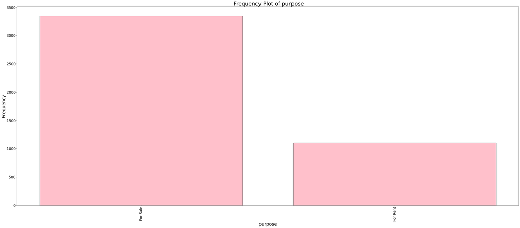

```python
bar_graph(data,"purpose")
```

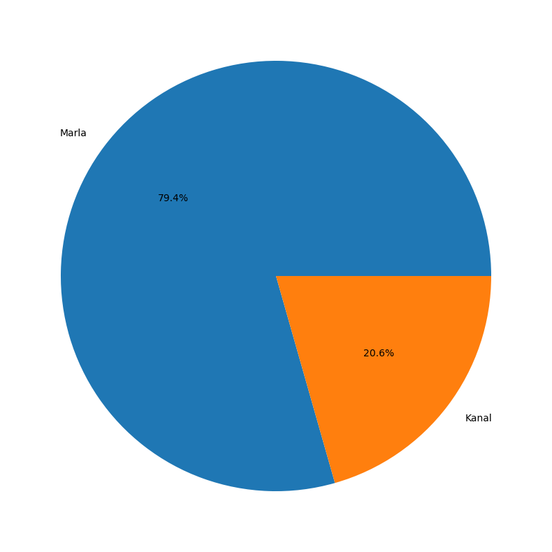

```python
a=data["Area Type"].value_counts()
pie_chart(data,"a")
```

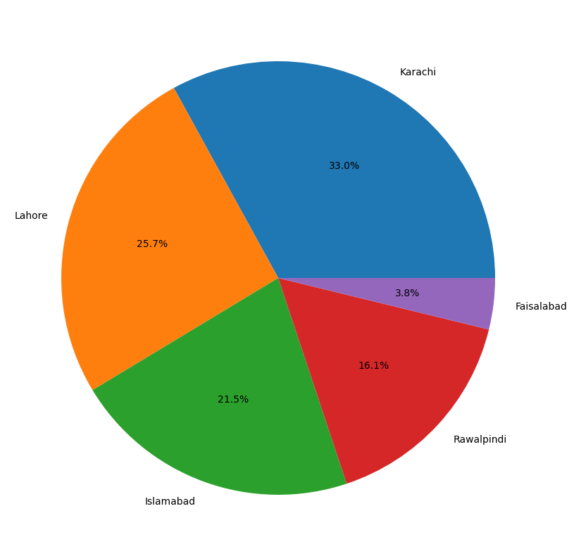

```python
#histogram(data,"city")
a=data["city"].value_counts()
pie_chart(data,"a")
```